# R assignment

Sushma Ambekar

## BCB546X-Spring 2021 R assignment

#### Installing and loading required libraries

```r
if (!require("tidyverse")) install.packages("tidyverse")
```

```r
if (!require("ggplot2")) install.packages("ggplot2")
if (!require("reshape2")) install.packages("reshape2")
if (!require("tidyr")) install.packages("tidyr")
if (!require("plyr")) install.packages("plyr")
if (!require("dplyr")) install.packages("dplyr")
library(tidyverse)
library(ggplot2)
library(reshape2)
library(tidyr)
library(plyr)
library(dplyr)
```

#### Obtaining required files from the class github repository

To get the data from the respository to R studio, I used the following code. It is important here to mention that the files have a header and are tab delimited

```r
fang_et_al_genotypes <- read.table("https://raw.githubusercontent.com/EEOB-BioData/BCB546-Spring2021/master/assignments/UNIX_Assignment/fang_et_al_genotypes.txt", header = TRUE, sep = "\t")
snp_position <- read.table("https://raw.githubusercontent.com/EEOB-BioData/BCB546-Spring2021/master/assignments/UNIX_Assignment/snp_position.txt", header = TRUE, sep = "\t")
```

#### File inspection

str() outputs the internal structure of an R object, a diagnostic function and an alternative to summary() dim() gives the lengths of rows and colummns colnames() displays the column names head() along with select() is being used here to show selected columns and rows

```r
head(fang_et_al_genotypes, n = 5) %>% select(1:5)
```

```
##   Sample_ID   JG_OTU Group abph1.20 abph1.22
## 1     SL-15 T-aust-1 TRIPS      ?/?      ?/?
## 2     SL-16 T-aust-2 TRIPS      ?/?      ?/?
## 3     SL-11 T-brav-1 TRIPS      ?/?      ?/?
## 4     SL-12 T-brav-2 TRIPS      ?/?      ?/?
## 5     SL-18   T-cund TRIPS      ?/?      ?/?
```

```r
str(fang_et_al_genotypes)
```

```
## 'data.frame':    2782 obs. of  986 variables:
##  $ Sample_ID     : chr  "SL-15" "SL-16" "SL-11" "SL-12" ...
##  $ JG_OTU        : chr  "T-aust-1" "T-aust-2" "T-brav-1" "T-brav-2" ...
##  $ Group         : chr  "TRIPS" "TRIPS" "TRIPS" "TRIPS" ...
##  $ abph1.20      : chr  "?/?" "?/?" "?/?" "?/?" ...
##  $ abph1.22      : chr  "?/?" "?/?" "?/?" "?/?" ...
##  $ ae1.3         : chr  "T/T" "T/T" "T/T" "T/T" ...
##  $ ae1.4         : chr  "G/G" "?/?" "G/G" "G/G" ...
##  $ ae1.5         : chr  "T/T" "T/T" "T/T" "T/T" ...
##  $ an1.4         : chr  "C/C" "C/C" "?/?" "C/C" ...
##  $ ba1.6         : chr  "?/?" "A/G" "G/G" "G/G" ...
##  $ ba1.9         : chr  "G/G" "G/G" "G/G" "G/G" ...
##  $ bt2.5         : chr  "?/?" "?/?" "C/C" "C/C" ...
##  $ bt2.7         : chr  "A/A" "A/A" "A/A" "A/A" ...
##  $ bt2.8         : chr  "?/?" "?/?" "?/?" "?/?" ...
```

[output cut: 86 more lines]

```r
dim(fang_et_al_genotypes)
```

```
## [1] 2782  986
```

```r
colnames(fang_et_al_genotypes)
```

```
##   [1] "Sample_ID"      "JG_OTU"         "Group"          "abph1.20"
##   [5] "abph1.22"       "ae1.3"          "ae1.4"          "ae1.5"
##   [9] "an1.4"          "ba1.6"          "ba1.9"          "bt2.5"
##  [13] "bt2.7"          "bt2.8"          "Fea2.1"         "Fea2.5"
##  [17] "id1.3"          "lg2.11"         "lg2.2"          "pbf1.1"
##  [21] "pbf1.2"         "pbf1.3"         "pbf1.5"         "pbf1.6"
##  [25] "pbf1.7"         "pbf1.8"         "PZA00003.11"    "PZA00004.2"
##  [29] "PZA00005.8"     "PZA00005.9"     "PZA00006.13"    "PZA00006.14"
##  [33] "PZA00008.1"     "PZA00010.5"     "PZA00013.10"    "PZA00013.11"
##  [37] "PZA00013.9"     "PZA00015.4"     "PZA00017.1"     "PZA00018.5"
##  [41] "PZA00029.11"    "PZA00029.12"    "PZA00030.11"    "PZA00031.5"
##  [45] "PZA00041.3"     "PZA00042.2"     "PZA00042.5"     "PZA00043.7"
##  [49] "PZA00045.1"     "PZA00047.2"     "PZA00049.12"    "PZA00050.9"
##  [53] "PZA00051.2"     "PZA00058.5"     "PZA00058.6"     "PZA00060.2"
##  [57] "PZA00061.1"     "PZA00065.2"     "PZA00069.4"     "PZA00070.5"
```

[output cut: 232 more lines]

```r
table(fang_et_al_genotypes$Group)
```

```
##
## TRIPS ZDIPL ZLUXR ZMHUE ZMMIL ZMMLR ZMMMR ZMPBA ZMPIL ZMPJA ZMXCH ZMXCP ZMXIL
##    22    15    17    10   290  1256    27   900    41    34    75    69     6
## ZMXNO ZMXNT ZPERR
##     7     4     9
```

```r
dim(snp_position)
```

```
## [1] 983  15
```

```r
str(snp_position)
```

```
## 'data.frame':    983 obs. of  15 variables:
##  $ SNP_ID              : chr  "abph1.20" "abph1.22" "ae1.3" "ae1.4" ...
##  $ cdv_marker_id       : int  5976 5978 6605 6606 6607 5982 3463 3466 5983 5985 ...
##  $ Chromosome          : chr  "2" "2" "5" "5" ...
##  $ Position            : chr  "27403404" "27403892" "167889790" "167889682" ...
##  $ alt_pos             : chr  "" "" "" "" ...
##  $ mult_positions      : chr  "" "" "" "" ...
##  $ amplicon            : chr  "abph1" "abph1" "ae1" "ae1" ...
##  $ cdv_map_feature.name: chr  "AB042260" "AB042260" "ae1" "ae1" ...
##  $ gene                : chr  "abph1" "abph1" "ae1" "ae1" ...
##  $ candidate.random    : chr  "candidate" "candidate" "candidate" "candidate" ...
##  $ Genaissance_daa_id  : int  8393 8394 8395 8396 8397 8398 8399 8400 8401 8402 ...
##  $ Sequenom_daa_id     : int  10474 10475 10477 10478 10479 10481 10482 10483 10486 10487 ...
##  $ count_amplicons     : int  1 0 1 0 0 1 1 0 1 0 ...
##  $ count_cmf           : int  1 0 1 0 0 1 0 0 1 0 ...
##  $ count_gene          : int  1 0 1 0 0 1 1 0 1 0 ...
```

```r
colnames(snp_position)
```

```
##  [1] "SNP_ID"               "cdv_marker_id"        "Chromosome"
##  [4] "Position"             "alt_pos"              "mult_positions"
##  [7] "amplicon"             "cdv_map_feature.name" "gene"
## [10] "candidate.random"     "Genaissance_daa_id"   "Sequenom_daa_id"
## [13] "count_amplicons"      "count_cmf"            "count_gene"
```

```r
head(snp_position, n = 5) %>% select(1:5)
```

```
##     SNP_ID cdv_marker_id Chromosome  Position alt_pos
## 1 abph1.20          5976          2  27403404
## 2 abph1.22          5978          2  27403892
## 3    ae1.3          6605          5 167889790
## 4    ae1.4          6606          5 167889682
## 5    ae1.5          6607          5 167889821
```

```r
table(snp_position$Chromosome)
```

```
##
##        1       10        2        3        4        5        6        7
##      155       53      127      107       91      122       76       97
##        8        9 multiple  unknown
##       62       60        6       27
```

To create separate files with required maize and teosinte IDs, I used the following codes:

```r
maize_IDs <- fang_et_al_genotypes[which(fang_et_al_genotypes$Group == "ZMMIL" | fang_et_al_genotypes$Group == "ZMMLR" | fang_et_al_genotypes$Group == "ZMMMR"),]
teosinte_IDs <- fang_et_al_genotypes[which(fang_et_al_genotypes$Group == "ZMPBA" | fang_et_al_genotypes$Group == "ZMPIL" | fang_et_al_genotypes$Group == "ZMPJA"),]
```

Since we require only three columns from the snp_position file, “SNP_ID”,“Chromosome” and “Position”, I combined the values of 1,3 and 4 columns into a new file

```r
snp_position_filtered <- snp_position[,c(1,3,4)]
```

In order to put the required files together, I first transposed them and added the row name, SNP_ID which will be the identifier while merging.

```r
transposed_maize_genotypes <- as.data.frame(t(maize_IDs[,-1]))
colnames(transposed_maize_genotypes) <- maize_IDs$Sample_ID
transposed_teosinte_genotypes <- as.data.frame(t(teosinte_IDs[,-1]))
colnames(transposed_teosinte_genotypes) <- teosinte_IDs$Sample_ID

transposed_maize_genotypes <- cbind(SNP_ID = row.names(transposed_maize_genotypes), transposed_maize_genotypes)
transposed_teosinte_genotypes <- cbind(SNP_ID = row.names(transposed_teosinte_genotypes), transposed_teosinte_genotypes)
```

Then, I merged the intermediate files by “SNP_ID” and row names maintaining the order, snp_position_filtered followed by maize and teosinte genotypes.

```r
maize_all_chromosomes <- merge(snp_position_filtered,transposed_maize_genotypes, by = "SNP_ID")
teosinte_all_chromosomes <- merge(snp_position_filtered,transposed_teosinte_genotypes, by = "SNP_ID")
```

Missing data in R is replaced by NA by default. I could not figure out how to do this while merging, so used the approach below.

```r
maize_all_chromosomes[maize_all_chromosomes=="NA"] <- "?/?"
teosinte_all_chromosomes[teosinte_all_chromosomes=="NA"] <- "?/?"
```

To sort our merged files by increasing and decreasing position, I used the the order() function.

```r
maize_all_chromosomes_increasing <- maize_all_chromosomes[order(maize_all_chromosomes$Position),]
teosinte_all_chromosomes_increasing <- teosinte_all_chromosomes[order(teosinte_all_chromosomes$Position),]
maize_all_chromosomes_decreasing <- maize_all_chromosomes[order(maize_all_chromosomes$Position,decreasing = T),]
teosinte_all_chromosomes_decreasing <- teosinte_all_chromosomes[order(teosinte_all_chromosomes$Position,decreasing = T),]
```

Then I used for loops to subset our datasets by chromosome and write to new files

```r
for (i in 1:10){
 merge_maize_chromosome <- maize_all_chromosomes_increasing[maize_all_chromosomes_increasing$Chromosome == i,]
  write.csv(merge_maize_chromosome, file=paste("maize_increasing_",i,".csv",sep=""))
}

for (i in 1:10){
  merge_maize_chromosome_rev <- maize_all_chromosomes_decreasing[maize_all_chromosomes_decreasing$Chromosome == i,]
  suppressWarnings(merge_maize_chromosome_rev[merge_maize_chromosome_rev == "?/?"] <- factor("-/-"))
  write.csv(merge_maize_chromosome_rev, file=paste("maize_decreasing_",i,".csv",sep=""))
}

for (i in 1:10){
  merge_teosinte_chromosome <- teosinte_all_chromosomes_increasing[teosinte_all_chromosomes_increasing$Chromosome == i,]
  write.csv(merge_teosinte_chromosome, file=paste("teosinte_increasing_",i,".csv",sep=""))
}

for (i in 1:10){
  merge_teosinte_chromosome_rev <- teosinte_all_chromosomes_decreasing[teosinte_all_chromosomes_decreasing$Chromosome == i,]
  suppressWarnings(merge_teosinte_chromosome_rev[merge_teosinte_chromosome_rev == "?/?"] <- factor("-/-"))
  write.csv(merge_teosinte_chromosome_rev, file=paste("teosinte_decreasing_",i,".csv",sep=""))
}
```

## Plots

#### SNPs per chromosome

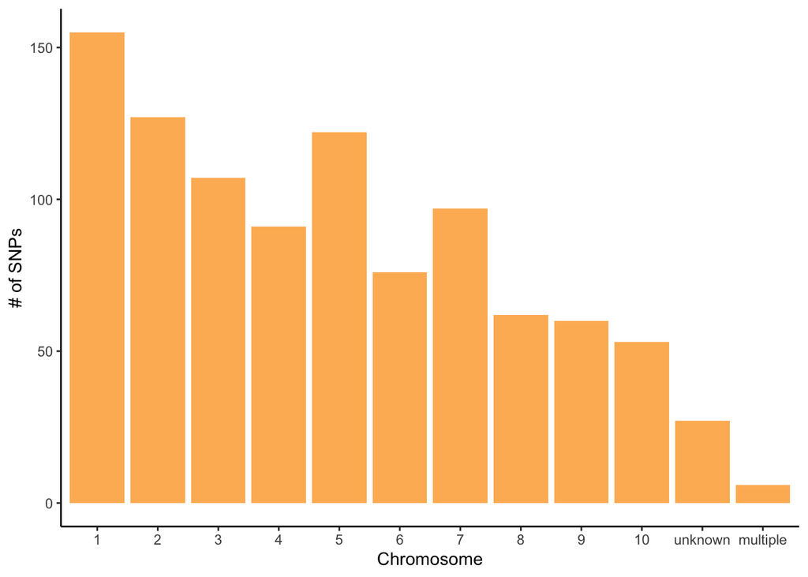

#### Distribuition of SNPs along chromosomes

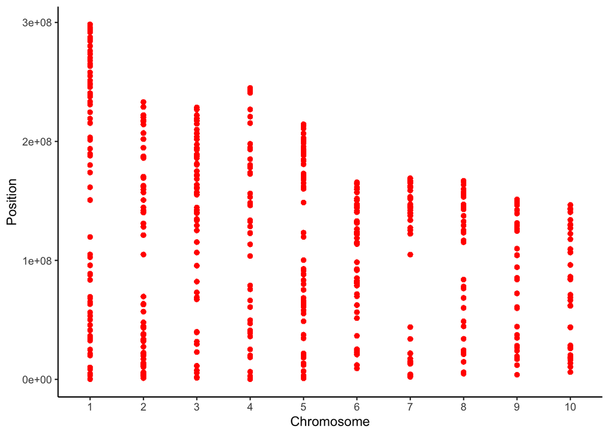

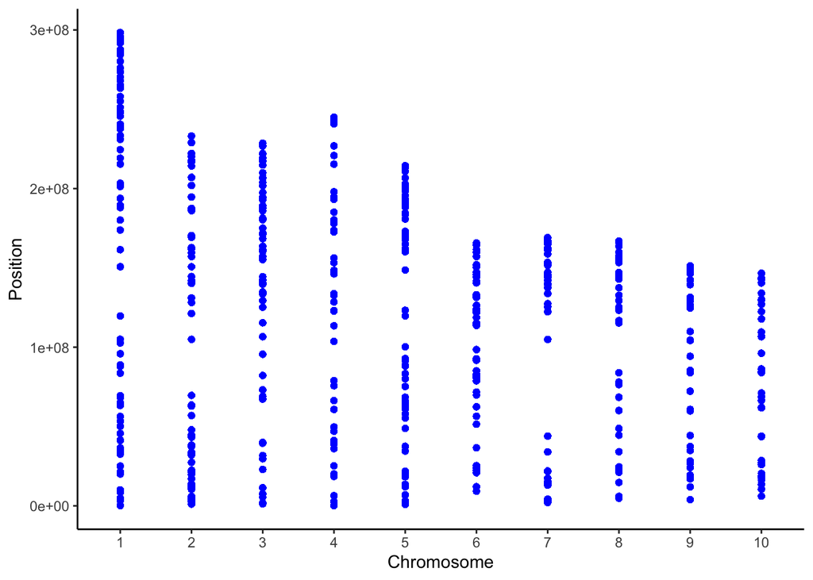

To plot missing data and heterozygosity, I first processed the files to show this data. So I created a new column that records whether the genotype characters match. In all of fang_et_al_genotypes, we can see a general proportion of homozygous to heterozygous to missing data.

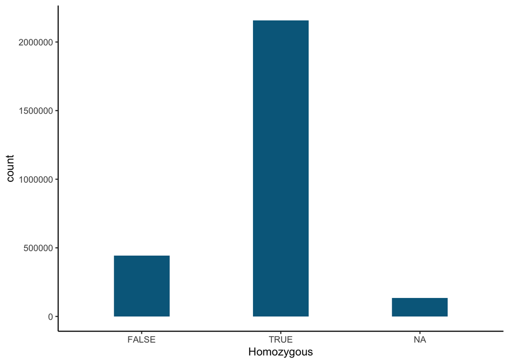

To group this data by the species and group I made some intermediate data frames.

To get the proportion of homo/heterozygosity for each ordered dataframe, I summarized the ‘Homozygous’ column.

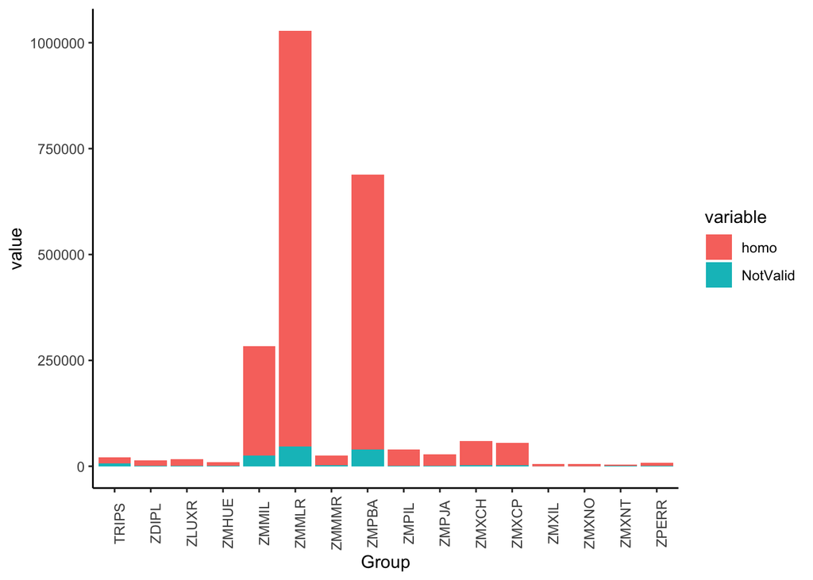

```r
fang_melted_group_prop <- ddply(fang_melted_group, c("Group"), summarise, homo=sum(Homozygous, na.rm=TRUE),
                     heter=sum(Homozygous, na.rm=FALSE), NotValid=sum(is.na(Homozygous)))
group_prop_melt <- melt(fang_melted_group_prop, measure.vars = c("homo", "heter", "NotValid"))
fang_melted_ID_prop <- ddply(fang_melted_ID, c("Sample_ID"), summarise, homo=sum(Homozygous, na.rm=TRUE),
                     heter=sum(Homozygous, na.rm=FALSE), NotValid=sum(is.na(Homozygous)))
ID_prop_melt <- melt(fang_melted_ID_prop, measure.vars = c("homo", "heter", "NotValid"))
ggplot(group_prop_melt,aes(x = Group, y= value, fill=variable)) + geom_bar(stat = "identity", position = "stack") + theme_classic() + theme(axis.text.x = element_text(angle = 90))
```

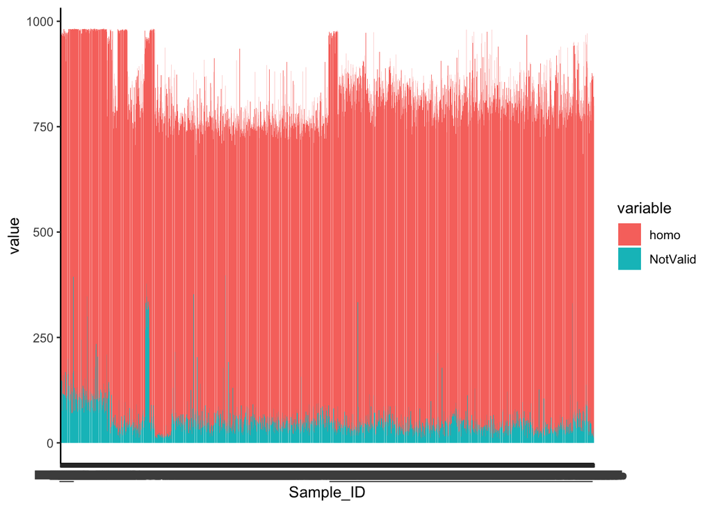

```r
ggplot(ID_prop_melt,aes(x = Sample_ID, y= value, fill=variable)) + geom_bar(stat = "identity", position = "stack") + theme_classic()
```

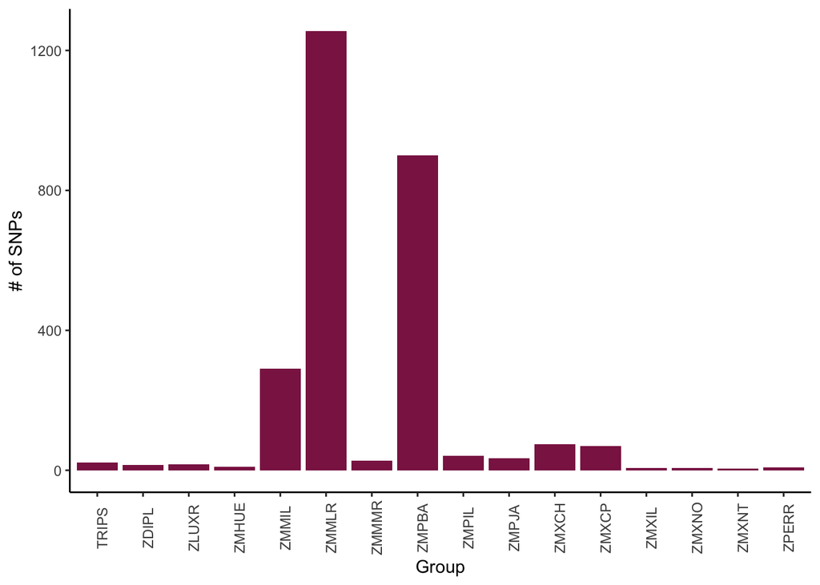

[output not shown]